# DoAnDMining_final

Nhóm 8

4/17/2022

# Predict Water Quality

## Thành Viên:

- Nguyễn Anh Đắc 19133020
- Nguyễn Thanh Tân Kỷ 19133031
- Lại Hữu Trác 19133059
- Đào Thị Cẩm Tiên 19133055

## Giới Thiệu

- Tiếp cận nước uống an toàn là điều cần thiết đối với sức khỏe, một quyền cơ bản của con người và là một thành phần của chính sách hiệu quả để bảo vệ sức khỏe.
- Đây là vấn đề quan trọng như một vấn đề sức khỏe và phát triển ở cấp quốc gia, khu vực và địa phương. Ở một số vùng, người ta đã chỉ ra rằng các khoản đầu tư vào cấp nước và vệ sinh có thể mang lại lợi ích kinh tế ròng, vì việc giảm các tác động xấu đến sức khỏe và chi phí chăm sóc sức khoẻ lớn hơn chi phí thực hiện các can thiệp.

## Data

- Dữ liệu chứa các chỉ số chất lượng nước, gồm 10 cột và 3276 dòng
- Các cột trong tập dữ liệu:
  - pH value: Độ pH của nước. WHO đã khuyến cáo giới hạn pH tối đa cho phép từ 6,5 đến 8,5
  - Hardness(mg/l): Độ cứng của nước. Độ cứng của nước được định nghĩa đơn giản nhất là loại nước có tổng lượng muối Ca và Mg được hòa tan trong nước vượt qua mức cho phép
  - Solids (Total dissolved solids - TDS): Tổng chất rắn hoà tan trong nước. giới hạn mong muốn cho TDS là 500 mg / l và giới hạn tối đa là 1000 mg / l được quy định cho mục đích uống
  - Chloramines: Mức clo lên đến 4 miligam mỗi lít (mg / L hoặc 4 phần triệu (ppm)) được coi là an toàn trong nước uống
  - Sulfate: lượng sulfate trong nước
  - Conductivity: tính dẫn điện.
  - Organic_carbon: lượng cacbon hữu cơ trong nước
  - Trihalomethanes: lượng THM trong nước. Đây là sản phẩm phụ của quá trình khử trùng nước bằng Chlorine.
  - Turbidity: Độ đục của nước
  - Potability: Cho biết liệu nước có an toàn cho con người hay không, trong đó 1 nghĩa là Uống được và 0 nghĩa là Không uống được

## Kế Hoạch Phân Tích

- Nhóm đặt ra câu hỏi nghiên cứu chung là tìm ra các yếu tố ảnh hưởng tới chất lượng nước: Dự đoán chất lượng nước (1: an toàn, 0: không an toàn)
- Dự đoán:
  - Input: pH, Hardness, Solids, Chloramines, Sulfate, Conductivity, Organic_carbon, Trihalomethanes, Turbidity.
  - Output: Potability.
- Chia tập train, tập test tỷ lệ 75% train và 25% test
- Trên tập train sẽ thử các thuật toán:
  - Knn
  - Random Forest
  - Logistic Regression
- Phương pháp sử dụng: K-fold Cross Validate
- Lựa chọn mô hình cho kết quả tốt nhất.
- Đánh giá mô hình trên tập test.

```r
library(ggplot2)
library(dplyr)
library(corrplot)
library(reshape2)
```

- Đọc file .csv

```r
df<- read.csv("Data/water_potability.csv")
```

- 6 dòng đầu

```r
head(df)
```

```
##         ph Hardness   Solids Chloramines  Sulfate Conductivity Organic_carbon
## 1       NA 204.8905 20791.32    7.300212 368.5164     564.3087      10.379783
## 2 3.716080 129.4229 18630.06    6.635246       NA     592.8854      15.180013
## 3 8.099124 224.2363 19909.54    9.275884       NA     418.6062      16.868637
## 4 8.316766 214.3734 22018.42    8.059332 356.8861     363.2665      18.436524
## 5 9.092223 181.1015 17978.99    6.546600 310.1357     398.4108      11.558279
## 6 5.584087 188.3133 28748.69    7.544869 326.6784     280.4679       8.399735
##   Trihalomethanes Turbidity Potability
## 1        86.99097  2.963135          0
## 2        56.32908  4.500656          0
## 3        66.42009  3.055934          0
## 4       100.34167  4.628771          0
## 5        31.99799  4.075075          0
## 6        54.91786  2.559708          0
```

- 6 dòng cuối

```r
tail(df)
```

```
##            ph Hardness   Solids Chloramines  Sulfate Conductivity
## 3271 6.069616 186.6590 26138.78    7.747547 345.7003     415.8870
## 3272 4.668102 193.6817 47580.99    7.166639 359.9486     526.4242
## 3273 7.808856 193.5532 17329.80    8.061362       NA     392.4496
## 3274 9.419510 175.7626 33155.58    7.350233       NA     432.0448
## 3275 5.126763 230.6038 11983.87    6.303357       NA     402.8831
## 3276 7.874671 195.1023 17404.18    7.509306       NA     327.4598
##      Organic_carbon Trihalomethanes Turbidity Potability
## 3271       12.06762        60.41992  3.669712          1
## 3272       13.89442        66.68769  4.435821          1
## 3273       19.90323              NA  2.798243          1
## 3274       11.03907        69.84540  3.298875          1
## 3275       11.16895        77.48821  4.708658          1
## 3276       16.14037        78.69845  2.309149          1
```

```r
#So Dong & Cot
dim(df)
```

```
## [1] 3276   10
```

```r
str(df)
```

```
## 'data.frame':    3276 obs. of  10 variables:
##  $ ph             : num  NA 3.72 8.1 8.32 9.09 ...
##  $ Hardness       : num  205 129 224 214 181 ...
##  $ Solids         : num  20791 18630 19910 22018 17979 ...
##  $ Chloramines    : num  7.3 6.64 9.28 8.06 6.55 ...
##  $ Sulfate        : num  369 NA NA 357 310 ...
##  $ Conductivity   : num  564 593 419 363 398 ...
##  $ Organic_carbon : num  10.4 15.2 16.9 18.4 11.6 ...
##  $ Trihalomethanes: num  87 56.3 66.4 100.3 32 ...
##  $ Turbidity      : num  2.96 4.5 3.06 4.63 4.08 ...
##  $ Potability     : int  0 0 0 0 0 0 0 0 0 0 ...
```

```r
summary(df)
```

```
##        ph            Hardness          Solids         Chloramines
##  Min.   : 0.000   Min.   : 47.43   Min.   :  320.9   Min.   : 0.352
##  1st Qu.: 6.093   1st Qu.:176.85   1st Qu.:15666.7   1st Qu.: 6.127
##  Median : 7.037   Median :196.97   Median :20927.8   Median : 7.130
##  Mean   : 7.081   Mean   :196.37   Mean   :22014.1   Mean   : 7.122
##  3rd Qu.: 8.062   3rd Qu.:216.67   3rd Qu.:27332.8   3rd Qu.: 8.115
##  Max.   :14.000   Max.   :323.12   Max.   :61227.2   Max.   :13.127
##  NA's   :491
##     Sulfate       Conductivity   Organic_carbon  Trihalomethanes
##  Min.   :129.0   Min.   :181.5   Min.   : 2.20   Min.   :  0.738
##  1st Qu.:307.7   1st Qu.:365.7   1st Qu.:12.07   1st Qu.: 55.845
##  Median :333.1   Median :421.9   Median :14.22   Median : 66.622
##  Mean   :333.8   Mean   :426.2   Mean   :14.28   Mean   : 66.396
##  3rd Qu.:360.0   3rd Qu.:481.8   3rd Qu.:16.56   3rd Qu.: 77.337
##  Max.   :481.0   Max.   :753.3   Max.   :28.30   Max.   :124.000
##  NA's   :781                                     NA's   :162
##    Turbidity       Potability
##  Min.   :1.450   Min.   :0.0000
##  1st Qu.:3.440   1st Qu.:0.0000
##  Median :3.955   Median :0.0000
##  Mean   :3.967   Mean   :0.3901
##  3rd Qu.:4.500   3rd Qu.:1.0000
##  Max.   :6.739   Max.   :1.0000
##
```

```r
#xử lý giá trị NA bằng cách thay bằng giá trị mean
df <- df %>%
  group_by(Potability) %>%
  mutate_at(vars(-c("Potability")),~ifelse(is.na(.), mean(., na.rm = TRUE), .))
summary(df)
```

```
##        ph            Hardness          Solids         Chloramines
##  Min.   : 0.000   Min.   : 47.43   Min.   :  320.9   Min.   : 0.352
##  1st Qu.: 6.278   1st Qu.:176.85   1st Qu.:15666.7   1st Qu.: 6.127
##  Median : 7.085   Median :196.97   Median :20927.8   Median : 7.130
##  Mean   : 7.081   Mean   :196.37   Mean   :22014.1   Mean   : 7.122
##  3rd Qu.: 7.870   3rd Qu.:216.67   3rd Qu.:27332.8   3rd Qu.: 8.115
##  Max.   :14.000   Max.   :323.12   Max.   :61227.2   Max.   :13.127
##     Sulfate       Conductivity   Organic_carbon  Trihalomethanes
##  Min.   :129.0   Min.   :181.5   Min.   : 2.20   Min.   :  0.738
##  1st Qu.:317.1   1st Qu.:365.7   1st Qu.:12.07   1st Qu.: 56.648
##  Median :334.6   Median :421.9   Median :14.22   Median : 66.304
##  Mean   :333.8   Mean   :426.2   Mean   :14.28   Mean   : 66.396
##  3rd Qu.:350.4   3rd Qu.:481.8   3rd Qu.:16.56   3rd Qu.: 76.667
##  Max.   :481.0   Max.   :753.3   Max.   :28.30   Max.   :124.000
##    Turbidity       Potability
##  Min.   :1.450   Min.   :0.0000
##  1st Qu.:3.440   1st Qu.:0.0000
##  Median :3.955   Median :0.0000
##  Mean   :3.967   Mean   :0.3901
##  3rd Qu.:4.500   3rd Qu.:1.0000
##  Max.   :6.739   Max.   :1.0000
```

```r
sum(is.na(df))
```

```
## [1] 0
```

```r
head(df)
```

```
## # A tibble: 6 x 10
## # Groups:   Potability [1]
##      ph Hardness Solids Chloramines Sulfate Conductivity Organic_carbon
##   <dbl>    <dbl>  <dbl>       <dbl>   <dbl>        <dbl>          <dbl>
## 1  7.09     205. 20791.        7.30    369.         564.          10.4
## 2  3.72     129. 18630.        6.64    335.         593.          15.2
## 3  8.10     224. 19910.        9.28    335.         419.          16.9
## 4  8.32     214. 22018.        8.06    357.         363.          18.4
## 5  9.09     181. 17979.        6.55    310.         398.          11.6
## 6  5.58     188. 28749.        7.54    327.         280.           8.40
## # ... with 3 more variables: Trihalomethanes <dbl>, Turbidity <dbl>,
## #   Potability <int>
```

## EDA

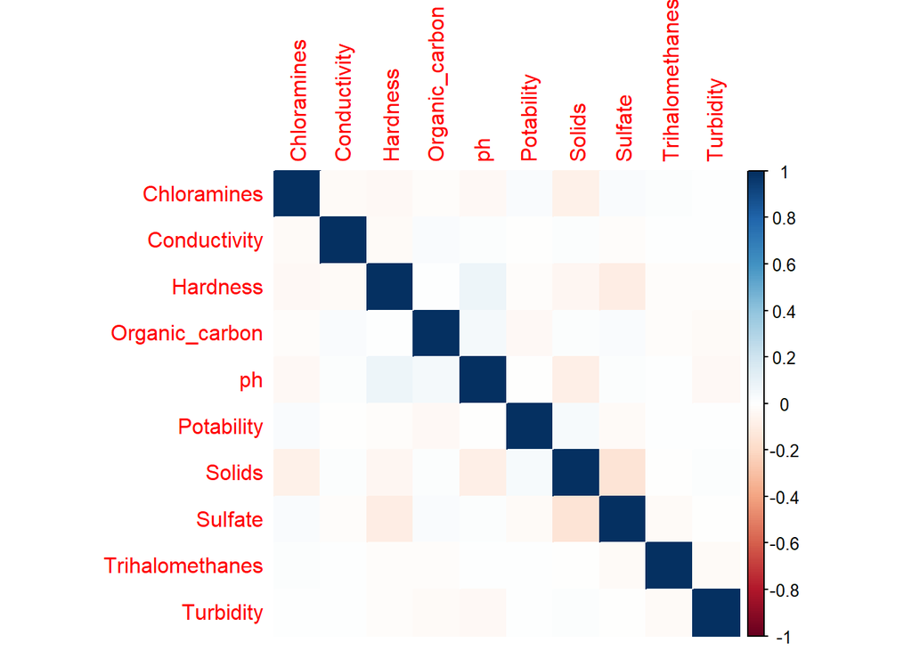

```r
corrplot(cor(df), method = 'color', order = 'alphabet')
```

### Biểu đồ Histogram

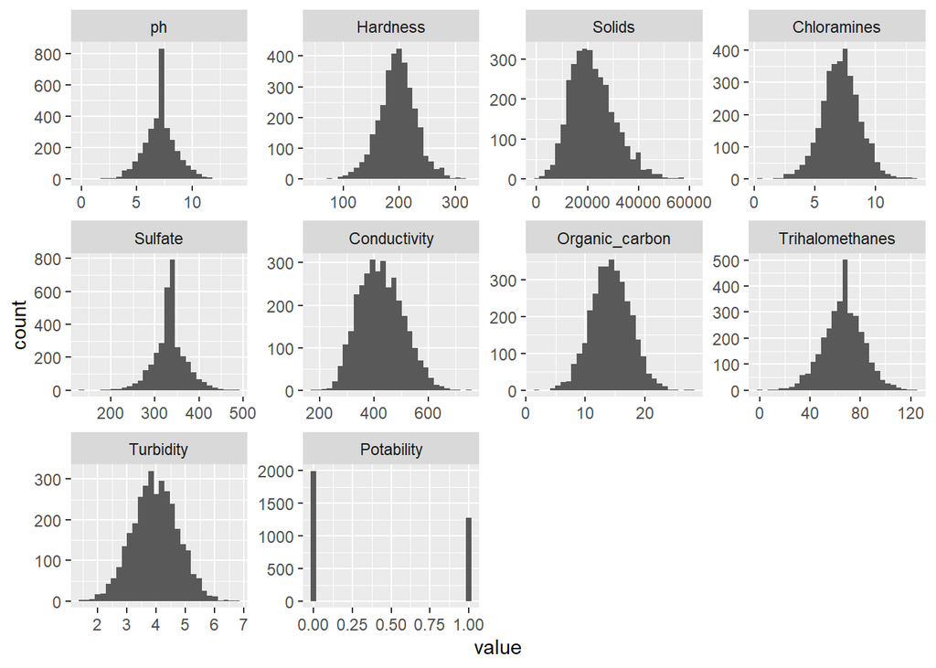

```r
melt(df) %>% ggplot(aes(value)) +
  geom_histogram() +
  facet_wrap(~ variable, scales="free")
```

- Với biểu đồ histogram ở trên chúng ta có thể thấy sự phân bố số liệu của các biển có trong tập dữ liệu: + Với biểu đồ của 3 biến ph, sulfate, Trihalomethanes chúng ta có thể thấy có sự phân bố không đồng đều, đây là hậu quả của việc quá nhiều giá trị NA và sau khi ta thấy giấ trị mean vào.

## Predict_Quality_Water

```r
df$Potability <- factor(df$Potability)
library(randomForest)
```

- Chúng ta sẽ thực hiện thao tác chia dữ liệu theo phương pháp chia phân tầng

```r
library(caret)
set.seed(222)

index <- createDataPartition(y = df$Potability, p = 0.75, list = FALSE)
training <- df[index, ]
testing <- df[-index, ]
```

### Biểu đồ Boxplot

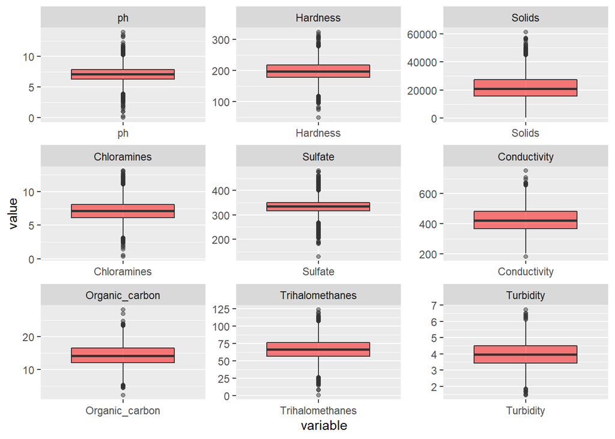

```r
melt(df) %>% ggplot(aes(variable,value)) +
  geom_boxplot(alpha = .5, fill = "red") +
  facet_wrap( ~ variable, scales="free")
```

- Với biểu đồ boxplot thì chúng ta có thể thấy sự xuất hiện của các outlier của các biển và nó khá nhiều. Nó có thể ảnh hưởng đến kết quả training của 1 số model như knn nên nhóm sẽ quyết định xử lý các outlier này.

#### Xử lý giá trị outlier

```r
datatrain<-training
#ph
Q1 <- quantile(datatrain$ph, .45)
Q3 <- quantile(datatrain$ph, .55)
IQR <- IQR(datatrain$ph)
no_outliers1 <- subset(datatrain, datatrain$ph> (Q1 - 1.5*IQR) & datatrain$ph< (Q3 + 1.5*IQR))
#Hardness
Q1 <- quantile(no_outliers1$Hardness, .35)
Q3 <- quantile(no_outliers1$Hardness, .65)
IQR <- IQR(no_outliers1$Hardness)
no_outliers2 <- subset(no_outliers1, no_outliers1$Hardness> (Q1 - 1.5*IQR) & no_outliers1$Hardness< (Q3 + 1.5*IQR))
#Solids
Q1 <- quantile(no_outliers2$Solids, .35)
Q3 <- quantile(no_outliers2$Solids, .65)
IQR <- IQR(no_outliers2$Solids)
no_outliers3 <- subset(no_outliers2, no_outliers2$Solids> (Q1 - 1.5*IQR) & no_outliers2$Solids< (Q3 + 1.5*IQR))
#Chloramines
Q1 <- quantile(no_outliers3$Chloramines, .35)
Q3 <- quantile(no_outliers3$Chloramines, .65)
IQR <- IQR(no_outliers3$Chloramines)
no_outliers4 <- subset(no_outliers3, no_outliers3$Chloramines> (Q1 - 1.5*IQR) & no_outliers3$Chloramines< (Q3 + 1.5*IQR))
#Sulfate
Q1 <- quantile(no_outliers4$Sulfate, .50)
Q3 <- quantile(no_outliers4$Sulfate, .50)
IQR <- IQR(no_outliers4$Sulfate)
no_outliers5 <- subset(no_outliers4, no_outliers4$Sulfate> (Q1 - 1.5*IQR) & no_outliers4$Sulfate< (Q3 + 1.5*IQR))
#Conductivity
Q1 <- quantile(no_outliers5$Conductivity, .25)
Q3 <- quantile(no_outliers5$Conductivity, .75)
IQR <- IQR(no_outliers5$Conductivity)
no_outliers6 <- subset(no_outliers5, no_outliers5$Conductivity> (Q1 - 1.5*IQR) & no_outliers5$Conductivity< (Q3 + 1.5*IQR))
#Organic_carbon
Q1 <- quantile(no_outliers6$Organic_carbon, .25)
Q3 <- quantile(no_outliers6$Organic_carbon, .75)
IQR <- IQR(no_outliers6$Organic_carbon)
no_outliers7 <- subset(no_outliers6, no_outliers6$Organic_carbon> (Q1 - 1.5*IQR) & no_outliers6$Organic_carbon< (Q3 + 1.5*IQR))
#Trihalomethanes
Q1 <- quantile(no_outliers7$Trihalomethanes, .35)
Q3 <- quantile(no_outliers7$Trihalomethanes, .65)
IQR <- IQR(no_outliers7$Trihalomethanes)
no_outliers8 <- subset(no_outliers7, no_outliers7$Trihalomethanes> (Q1 - 1.5*IQR) & no_outliers7$Trihalomethanes< (Q3 + 1.5*IQR))
#Turbidity
Q1 <- quantile(no_outliers8$Turbidity, .25)
Q3 <- quantile(no_outliers8$Turbidity, .75)
IQR <- IQR(no_outliers8$Turbidity)
no_outliers9 <- subset(no_outliers8, no_outliers8$Turbidity> (Q1 - 1.5*IQR) & no_outliers8$Turbidity< (Q3 + 1.5*IQR))
datatrain_knn <- no_outliers9
datatrain_lr <- no_outliers9
```

### Biểu đồ boxplot sau khi xử lý các outlier

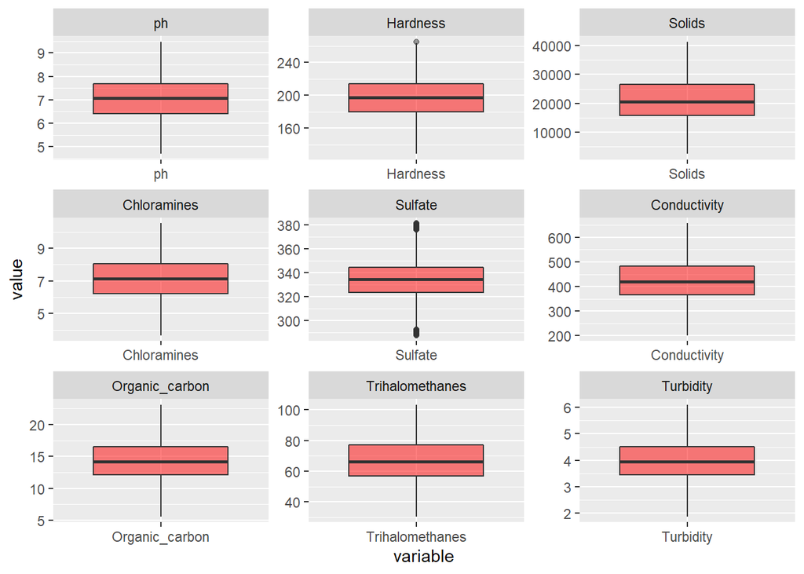

```r
melt(no_outliers9) %>% ggplot(aes(variable,value)) +
  geom_boxplot(alpha = .5, fill = "red") +
  facet_wrap( ~ variable, scales="free")
```

- Biểu đô boxplot ở trên là biểu đồ sau khi nhóm đã thực hiện xử lý các outliers. Nhưng vẫn còn sót lại 1 số outliers ở biến sulfate. Có thể là do ở biến này các outliers xuất hiện quá nhiều nên thành ra không thể xóa hết được, hoặc là mình sử dụng phép tính chưa tối ưu, nhưng chắc sẽ không ảnh hưởng quá nhiều đến kết quả training model.

## Random Forest

```r
set.seed(122)
trControl <- trainControl(method = "repeatedcv", number = 5, repeats =  3 )
tunegrid = expand.grid(mtry = c(2:4))
potability_rf <- train(Potability ~., data = training, method = 'rf', tuneGrid = tunegrid,ntree=500, trControl = trControl)
potability_rf
```

```
## Random Forest
##
## 2458 samples
##    9 predictor
##    2 classes: '0', '1'
##
## No pre-processing
## Resampling: Cross-Validated (5 fold, repeated 3 times)
## Summary of sample sizes: 1966, 1966, 1966, 1968, 1966, 1966, ...
## Resampling results across tuning parameters:
##
##   mtry  Accuracy   Kappa
##   2     0.7828918  0.5223765
##   3     0.7861430  0.5316973
##   4     0.7861414  0.5330998
##
## Accuracy was used to select the optimal model using the largest value.
## The final value used for the model was mtry = 3.
```

- Dưới đây là độ quan trọng của các biến ctheo thứ tự giảm dần là sulfate, ph, solids, Chloramines ,Hardness, Trihalomethanes, Conductivity, Organic_carbon,Turbidity.

```r
varImp(potability_rf)
```

```
## rf variable importance
##
##                 Overall
## Sulfate         100.000
## ph               50.657
## Solids            9.035
## Chloramines       8.906
## Hardness          8.719
## Trihalomethanes   2.737
## Conductivity      1.662
## Organic_carbon    1.115
## Turbidity         0.000
```

```
## mtry = 3  OOB error = 22.5%
## Searching left ...
## mtry = 2     OOB error = 24.37%
## -0.08318264 0.05
## Searching right ...
## mtry = 4     OOB error = 23.15%
## -0.02893309 0.05
```

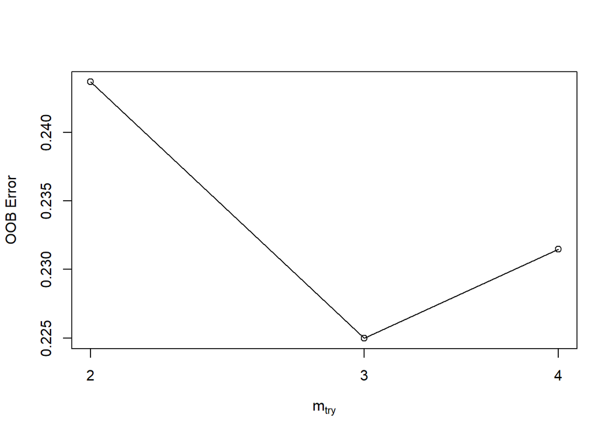

```r
t <- tuneRF(training[,-10], training$Potability, stepFactor = 1.5, plot = TRUE)
```

- Nhìn vào biểu đồ thì chúng ta thấy tham số mtry tốt nhất của mô hình là 3. Và chúng ta sẽ chọn nó để train mô hình.

```r
potability_rf
```

```
## Random Forest
##
## 2458 samples
##    9 predictor
##    2 classes: '0', '1'
##
## No pre-processing
## Resampling: Cross-Validated (5 fold, repeated 3 times)
## Summary of sample sizes: 1966, 1966, 1966, 1968, 1966, 1966, ...
## Resampling results across tuning parameters:
##
##   mtry  Accuracy   Kappa
##   2     0.7828918  0.5223765
##   3     0.7861430  0.5316973
##   4     0.7861414  0.5330998
##
## Accuracy was used to select the optimal model using the largest value.
## The final value used for the model was mtry = 3.
```

- Nhận xét: với mô hình Random Forest cho độ chính xác accurancy là khoảng 79%, giá trị chưa thực sự quá tốt, chúng ta sẽ tiếp tục thử nghiệm với mô hình khác.

## KNN

```r
tuneGrid <- expand.grid(k = seq(101,131, by = 2))

#Mô hình knn
knn <- train(Potability ~., data = datatrain_knn, method = 'knn', tuneGrid = tuneGrid, trControl = trControl)
knn
```

```
## k-Nearest Neighbors
##
## 1594 samples
##    9 predictor
##    2 classes: '0', '1'
##
## No pre-processing
## Resampling: Cross-Validated (5 fold, repeated 3 times)
## Summary of sample sizes: 1275, 1276, 1275, 1275, 1275, 1275, ...
## Resampling results across tuning parameters:
##
##   k    Accuracy   Kappa
##   101  0.6313276  2.931166e-03
##   103  0.6315366  2.163822e-03
##   105  0.6311186  1.027817e-03
##   107  0.6323725  3.518064e-03
##   109  0.6323725  2.921492e-03
##   111  0.6334168  4.079621e-03
##   113  0.6325822  2.138736e-03
##   115  0.6321635  2.201746e-03
##   117  0.6332091  5.452867e-03
##   119  0.6323732  2.025436e-03
##   121  0.6315366  4.513912e-05
##   123  0.6323725  3.215177e-03
##   125  0.6319552  2.100272e-03
##   127  0.6336291  6.327761e-03
##   129  0.6327912  3.750930e-03
##   131  0.6330001  4.157700e-03
##
## Accuracy was used to select the optimal model using the largest value.
## The final value used for the model was k = 127.
```

- Với mô hình KNN cho độ chính xác accurancy là khoảng 63%, giá trị thực sự chưa tốt, chúng ta sẽ tiếp tục thử nghiệm với mô hình khác.

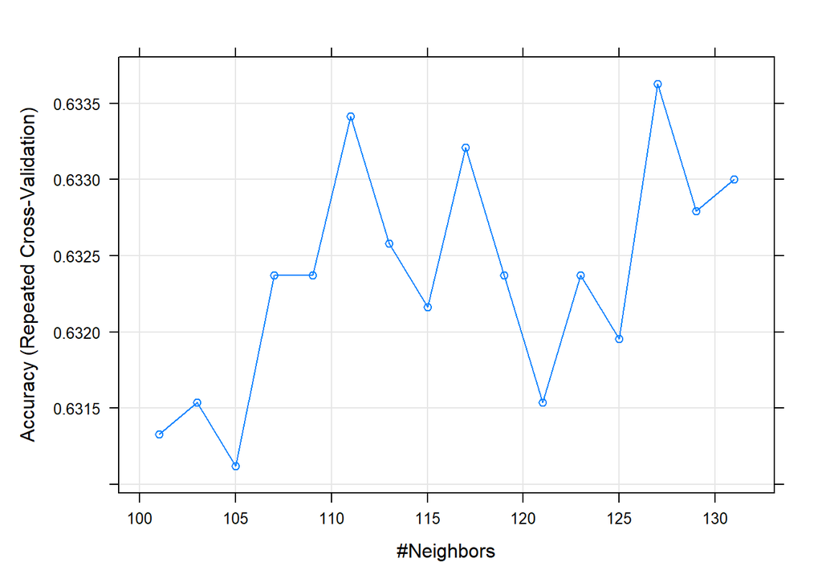

```r
plot(knn)
```

## Mô Hình Logistic Regression

```r
# Logistic regression
set.seed(1)

datatrain <- datatrain_lr %>% mutate_at(c("ph", "Solids","Sulfate","Chloramines","Hardness"), ~(scale(.)))
datatrain
```

```
## # A tibble: 1,594 x 10
## # Groups:   Potability [2]
##      ph[,1] Hardness[,1] Solids[,1] Chloramines[,1] Sulfate[,1] Conductivity
##       <dbl>        <dbl>      <dbl>           <dbl>       <dbl>        <dbl>
##  1  0.0285         0.330    -0.0571           0.123     1.74            564.
##  2  0.988          1.09     -0.176            1.56     -0.00746         419.
##  3 -1.39          -0.321     1.02             0.300    -0.414           280.
##  4  1.50           0.270    -1.02            -1.86     -1.62            475.
##  5  0.870          0.872    -0.330            0.711    -0.00746         364.
##  6  0.0285        -1.82      0.825           -0.212    -1.82            380.
##  7  0.417          0.348     0.968           -1.49     -0.00746         445.
##  8 -0.670         -0.383     2.68             1.81      1.54            517.
##  9 -0.00328        0.572     1.32             2.15     -0.00746         315.
## 10  0.0285         1.21      0.147            2.32     -0.00746         555.
## # ... with 1,584 more rows, and 4 more variables: Organic_carbon <dbl>,
## #   Trihalomethanes <dbl>, Turbidity <dbl>, Potability <fct>
```

```r
#train
potability_lr <- train(Potability ~ ph+ Sulfate+ Solids+ Chloramines+ Hardness, method = "glm", data = datatrain_lr,
                      trControl = trainControl(method = 'repeatedcv', number = 10, repeats = 3))
potability_lr
```

```
## Generalized Linear Model
##
## 1594 samples
##    5 predictor
##    2 classes: '0', '1'
##
## No pre-processing
## Resampling: Cross-Validated (10 fold, repeated 3 times)
## Summary of sample sizes: 1435, 1434, 1435, 1435, 1435, 1435, ...
## Resampling results:
##
##   Accuracy   Kappa
##   0.6336321  0
```

- Nhận xét: với mô hình Logistic Regression cho độ chính xác accurancy là 63.3%, giá trị này khá thấp.

## Thực Hiện Dự Đoán Trên Tập Test

- Tiến hành kiểm tra trên tâp test

```r
# Prediction on test-dataset
predicted_outcomes_rf <- predict(potability_rf, testing)


# Create Confusion Matrices
rf_confm <- confusionMatrix(predicted_outcomes_rf, testing$Potability)

rf_confm
```

```
## Confusion Matrix and Statistics
##
##           Reference
## Prediction   0   1
##          0 452 105
##          1  47 214
##
##                Accuracy : 0.8142
##                  95% CI : (0.7858, 0.8403)
##     No Information Rate : 0.61
##     P-Value [Acc > NIR] : < 2.2e-16
##
##                   Kappa : 0.5962
##
##  Mcnemar's Test P-Value : 3.777e-06
##
##             Sensitivity : 0.9058
##             Specificity : 0.6708
##          Pos Pred Value : 0.8115
##          Neg Pred Value : 0.8199
##              Prevalence : 0.6100
##          Detection Rate : 0.5526
##    Detection Prevalence : 0.6809
##       Balanced Accuracy : 0.7883
##
##        'Positive' Class : 0
##
```

- Dựa vào confusion Matrix chúng ta thấy tổng số dự đoán đúng của mô hình Random Forest khoảng hơn 660 trường hợp, dự đoán sai khoảng 150 trường hợp.
- Và mô hình này cho độ chính xác khoảng hơn 81%

## Kết luận:

- Mô hình Random Forest là mô hình cho kết quả tốt nhất với độ chính xác khoảng 81% trong 3 mô hình mà nhóm em thử huấn luyện mô hình.
- Dù độ chính xác chưa cao lắm nhưng có thể dùng nó để khảo sát sàng lọc trước
- Tiếp tục phát triển đề tài, nhóm em sẽ tiếp tục sử các phương pháp, độ đo khác cũng như thử nghiệm các mô hình khác để cải thiện mô hình dự đoán được chính xác hơn